```python
from IPython.display import Image
```

# k-Nearest Neighbors (kNN) - Theory

## kNN - Overview

The kNN algorithm is a supervised classification method that assumes that data points near each other are similar to one another.

The proximity of data points is calcualted using Euclidean distance. Suppose we have two points A and B. The distance is:

- $d(A,B)=\sqrt{\sum_i(X_i(A)-X_i(B))^2}$

We can also make a weighted distance, in the event that some features are more important than others (for example, a person's FICO score might be weighted higher than how many loans they've received in the past when determining whether or not they should receive a loan). A weighted distance function would look like:

- $d(A,B)=\frac{1}{\sum_jw_j}\sqrt{\sum_iw_i^2(X_i(A)-X_i(B))^2}$

From there, kNN can be broken down into two steps:

1. Find the closest $k$ neighbors
2. The predicted response is the average response of the $k$ neighbors

## Classification

In classification, we estimate the conditional probability that a point $y_i$ is of class $j$ by taking the average of the classifications of the $K$ closest points. This can be expressed as:

- - $\frac{1}{K}\sum_{i\in N(x_0)} I(y_i = j)$ where $N(x_0)$ represents the set of indices of the $K$ closest points

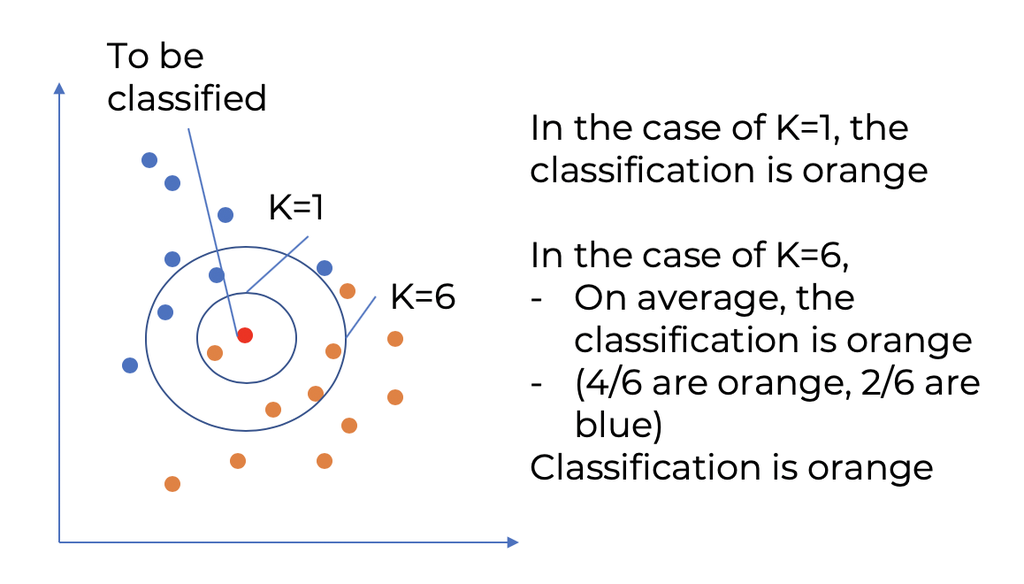

```python
Image("img/knn.png")
```

## Regression

kNN can also be used in regression by taking the expected response through an average.

- $\frac{1}{K}\sum_{i\in N(x_0)} y_i$ where $N(x_0)$ represents the set of indices of the $K$ closest points

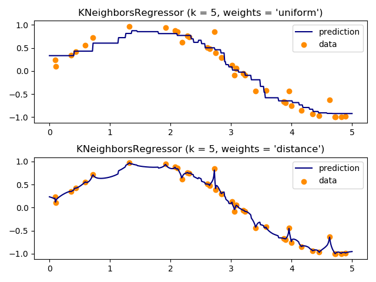

```python
Image("img/knn_regression.png")
```

Source: sklearn documentation

## More Resources

[Basics of kNN Classification and Regression](https://towardsdatascience.com/the-basics-knn-for-classification-and-regression-c1e8a6c955)

[kNN In-Depth>](https://www.analyticsvidhya.com/blog/2018/03/introduction-k-neighbours-algorithm-clustering/)